# Praca domowa nr. 5

Mateusz Grzyb

03.12.19

## Wstęp

Celem przeprowadzonego przeze mnie eksperymentu było zbadanie, jak różne typy wykresów wpływają na poprawność odczytywania proporcji przez odbiorców. W tym celu przygotowałem cztery różne wykresy, przedstawiające te same dane, sprawdziłem ich odbiór (używając ankiet Google), a następnie przeanalizowałem wyniki.

Prezentowane poniżej grafiki są czytelne na 24 calowym ekranie FHD w trybie pełnoekranowym.

## Dane

Do przygotowania wykresów użyłem danych o podziale światowej produkcji energii elektrycznej w 2018 roku względem jej źródła.

Źródło danych: https://www.iea.org/geco/electricity/

## Wykresy

Poniżej przedstawiam cztery wykresy, przygotowane w celu umieszczenia ich w ankiecie:

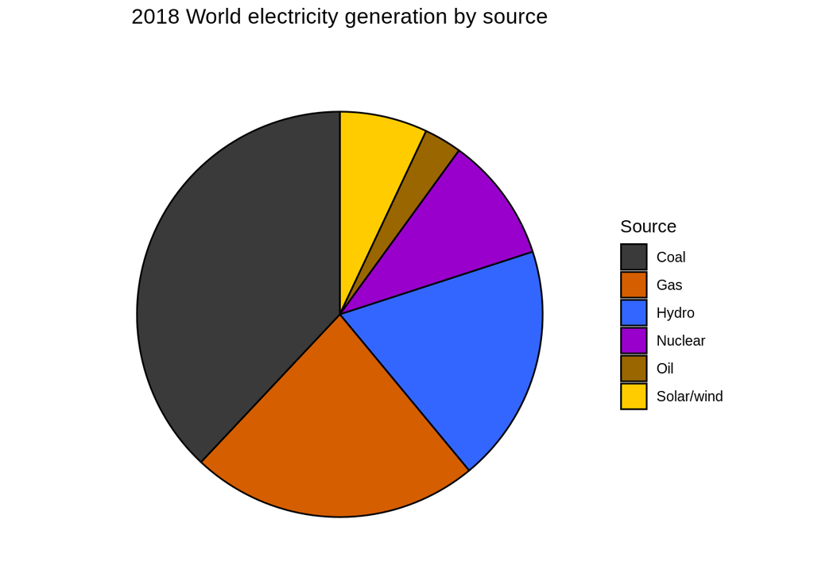

```r
theme_set(theme_classic())

palette <- c("#3a3a3a", "#d55E00", "#3366ff", "#9900cc", "#996600", "#ffcc00")

pie <- ggplot(data, aes(x = "", y=Percent, fill = factor(Source))) +
  geom_bar(width = 1, stat = "identity", color = "black") +
  theme(axis.line = element_blank(),
        plot.title = element_text(hjust=0.5),
        axis.ticks = element_blank(),
        axis.text = element_blank()) +
  labs(fill="Source",
       x=NULL,
       y=NULL,
       title="2018 World electricity generation by source",
       subtitle ="") +
  scale_fill_manual(values=palette)

pie + coord_polar(theta = "y", start=0)
```

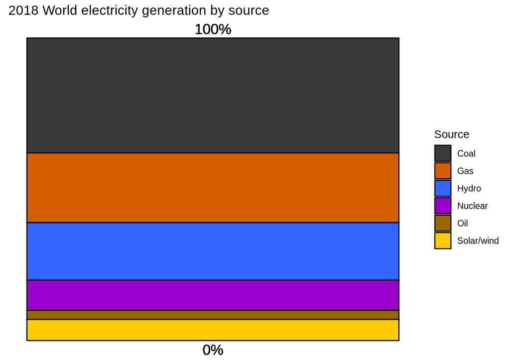

```r
palette <- c("#3a3a3a", "#d55E00", "#3366ff", "#9900cc", "#996600", "#ffcc00")

bar <- ggplot(data, aes(x=0, fill=Source, y=Percent)) +
  geom_bar(position="fill", stat="identity", color = "black") +
  scale_fill_manual(values=palette) +
  geom_text(x=0, y=1.03, size = 5, label="100%") +
  geom_text(x=0, y=-0.03, size = 5, label="0%") +
  labs(title="2018 World electricity generation by source", fill = "Source") +
  theme(axis.title = element_blank(),
        axis.line = element_blank(),
        axis.text = element_blank(),
        axis.ticks = element_blank(),
        legend.position = "right")

bar
```

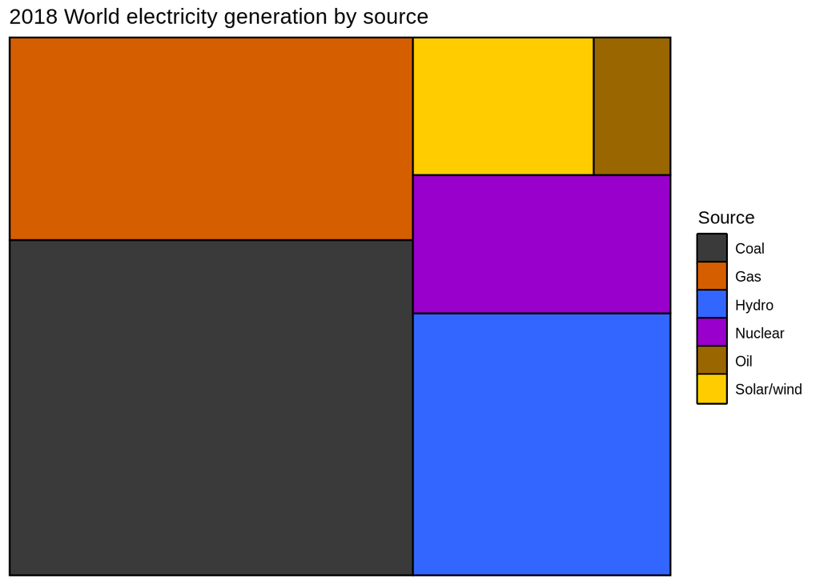

```r
palette <- c("#3a3a3a", "#d55E00", "#3366ff", "#9900cc", "#996600", "#ffcc00")

tree <- ggplot(data, aes(area = Percent, fill = Source, layout = "squarified")) +
  geom_treemap(color = "black", size = 1.5) +
  scale_fill_manual(values=palette) +
  labs(title="2018 World electricity generation by source", fill = "Source") +
  theme(axis.line = element_blank(),
        panel.border = element_rect(color = "black", fill = NA, size = 1),
        legend.key = element_rect(fill = NA, color = "black", size = 1))

tree
```

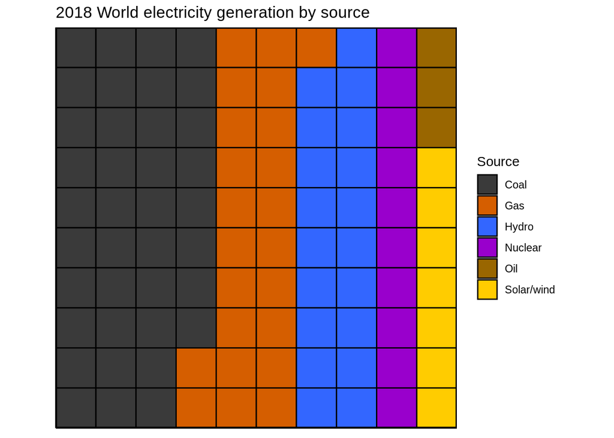

```r
var <- rep(data$Source, data$Percent)
df <- expand.grid(y = 1:10, x = 1:10)
categ_table <- round(table(var) * ((10*10)/(length(var))))
df$category <- factor(rep(names(categ_table), categ_table))

palette <- c("#3a3a3a", "#d55E00", "#3366ff", "#9900cc", "#996600", "#ffcc00")

waffle <- ggplot(df, aes(x = x, y = y, fill = category)) +
  geom_tile(color = "black", size = 0.5) +
  scale_x_continuous(expand = c(0, 0)) +
  scale_y_continuous(expand = c(0, 0), trans = 'reverse') +
  scale_fill_manual(values=palette) +
  labs(title="2018 World electricity generation by source", fill = "Source") +
  theme(panel.border = element_rect(size = 1, fill = NA),
        axis.text = element_blank(),
        axis.title = element_blank(),
        axis.ticks = element_blank(),
        legend.position = "right")

waffle + coord_fixed()
```

## Ankieta

Link do ankiety: https://forms.gle/XNbsDw72KJvaYRV69

Ankietę wypełniło 20 osób, w tym głównie inni studenci.

Podczas tworzenia ankiety przyświecały mi następujące założenia:

- w celu zminimalizowania szansy na nieumyślną pomyłkę ze strony odbiorcy, wykresy należy utrzymać w zbliżonym stylu, używać jednego schematu kolorystycznego, unikać zbędnych ozdobników
- wykresy należy umieścić w kolejności zgodnej ze spodziewanymi wynikiami, tak, by ankietowany nie sugerował się odpowiedzią udzieloną z użyciem teoretycznie precyzyjniejszego wykresu (i tak pie_chart jest przed bar_plotem, a tree_map przed waffle_chartem)
- by uzyskać ciekawsze wyniki lepiej nie pytać o zmienne, których udział jest bliski 25% / 50% / 75% (zbyt łatwo byłoby rozpoznać te wartości na wykresie kołowym)

## Wyniki

Poniżej prezentuję wyniki ankiety. Na dwóch wykresach przedstawiłem ilość poszczególnych odpowiedzi dla każdego rodzaju wykresu i obu źródeł energii, o które pytałem ankietowanych. Dodatkowo, kolorem zielonym oznaczyłem odpowiedzi poprawne, niebieskim prawie poprawne, a czerwonym dalekie od rzeczywistości.

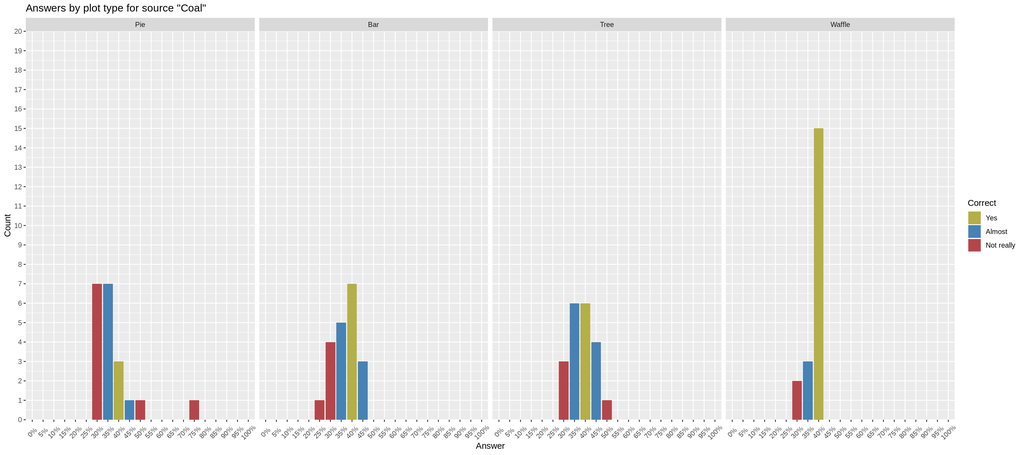

```r
poll_data <- poll_data %>%
  melt() %>%
  mutate(Correct = if_else(source == "Coal" & variable == "X40." | source == "Nuclear" & variable == "X10.", "Yes",
                           if_else(source == "Coal" & variable %in% c("X35.", "X45.") | source == "Nuclear" & variable %in% c("X5.", "X15."), "Almost", "Not really"))) %>%
  mutate(wykres = factor(wykres, levels=c("Pie", "Bar", "Tree", "Waffle"))) %>%
  mutate(Correct = factor(Correct, levels=c("Yes", "Almost", "Not really")))

theme_set(theme_gray())

ggplot(filter(poll_data, source == 'Coal'), aes(x = variable, y = value, fill = Correct)) +
  geom_col() +
  scale_y_continuous(limits = c(0,20), breaks = seq(0,20,1), expand = c(0, 0)) +
  scale_x_discrete(label = paste0(seq(0,100,5), rep("%", 20))) +
  scale_fill_manual(values = c("#B4AF46", "#4682B4", "#B4464B")) +
  theme(axis.text.x = element_text(angle = 45, vjust=0.5)) +
  xlab("Answer") +
  ylab("Count") +
  labs(title = "Answers by plot type for source \"Coal\"") +
  facet_grid(cols = vars(wykres), )
```

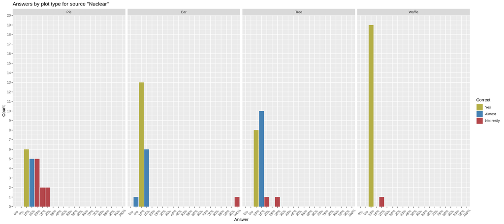

```r
ggplot(filter(poll_data, source == 'Nuclear'), aes(x = variable, y = value, fill = Correct)) +
  geom_col() +
  scale_y_continuous(limits = c(0,20), breaks = seq(0,20,1), expand = c(0, 0)) +
  scale_x_discrete(label = paste0(seq(0,100,5), rep("%", 20))) +
  scale_fill_manual(values = c("#B4AF46", "#4682B4", "#B4464B")) +
  theme(axis.text.x = element_text(angle = 45, vjust=0.5)) +
  xlab("Answer") +
  ylab("Count") +
  labs(title = "Answers by plot type for source \"Nuclear\"") +
  facet_grid(cols = vars(wykres), )
```

## Analiza

Wyniki ankiety wydały mi się trudne do dokładnego przeanalizowania wyłącznie “na oko”. Z powyższego powodu zdecydowałem się policzyć wymyślony przeze mnie indeks dla każdej kombinacji wykresu i źródla energii, o które pytałem ankietowanych. Wartości wspomnianego indeksu są z przedziału (0, 1) i wyznaczane są w następujący sposób: jest to średnia ważona, w której wartościami są liczby poszczególnych odpowiedzi, a wagami odwrotności odległości tych odpowiedzi od odpowiedzi poprawnej (tak, że odpowiedź poprawna ma wagę 1). Dokładny wzór można odczytać z poniższego kodu:

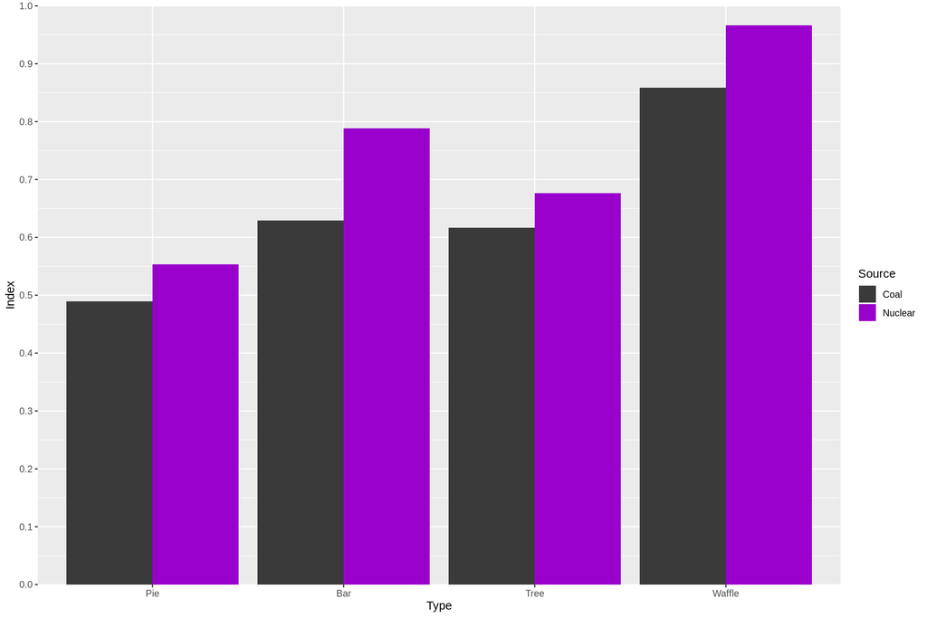

```r
poll_data <- mutate(poll_data, variable = as.numeric(stri_extract(variable, regex = "\\d+")))
indexes <- data.frame(Type=character(), Source=character(), Index=numeric())
for (x in unique(pull(poll_data, wykres))) {
  for (y in unique(pull(poll_data, source))) {
    data <- filter(poll_data, wykres == x & source == y)
    mid = pull(filter(data, Correct == "Yes"), variable)
    index = 0
    for(z in pull(data, variable)) {
      weight = ifelse(z == mid, 1, 1/((abs(mid-z)/5)+1))
      index = index + pull(data, value)[match(z, pull(data, variable))]*weight
    }
    index = index/sum(filter(select(data, value), value != 0))
    indexes <- bind_rows(indexes, tibble(Type=x, Source=y, Index=index))
  }
}

indexes <- mutate(indexes, Type = factor(Type, levels=c("Pie", "Bar", "Tree", "Waffle")))

ggplot(indexes, aes(x = Type, y = Index, fill = Source)) +
  geom_col(position = "dodge") +
  scale_y_continuous(breaks = seq(0,1,0.1), limits = c(0,1), expand = c(0,0)) +
  scale_fill_manual(values = c("#3a3a3a", "#9900cc"))
```

## Wnioski

Myślę, że po przeprowadzonej analizie, śmiało mogę wysnuć następujący wniosek - w przypadku prezentowania proporcji, w kontekście precyzji odczytywania, zachodzi następująca zależność:

pie_chart < tree_map < bar_plot < waffle_chart

Powyższy wniosek jest, między innymi, zgodny z wykładem - człowiek lepiej porównuje długości od kątów (a najlepiej zlicza kratki ;)). Ponadto, za ciekawą uważam obserwację, że odczytywanie niskich frakcji wypadło lepiej od odczytywania wysokich, dla każdego typu wykresu. W ankiecie pytałem także o płeć i wiek, ale wpływ tych czynników na odpowiedzi okazał się być marginalny.